# Линейные модели с непрерывными и дискретными предикторами

## Мы рассмотрим

- Линейные модели c непрерывными и дискретными предикторами
- Простейший экспериментальный план, требующий анализа ковариации (ANCOVA)

### Вы сможете

- Написать на языке R код, необходимый для подгонки линейной модели, включающей дискретные и непрерывные предикторы, а так же их взаимодействие
- Дать трактовку коэффициентам такой линейной модели

## Пример: Клевер и тысячелистник

Тысячелистник *Achillea millefolium* часто растет как сорняк на полях вместе с клевером *Trifolium repens*. Зависит ли урожай клевера от плотности тысячелистника?

```r
clover <- read.delim("data/clover.csv")
names(clover)
```

```
## [1] "Area"         "Clover.yield" "Yarrow.stems"
```

```r
# Для удобства переименуем переменные
names(clover) <- c("Plot", "Clover", "Yarrow")
```

- Plot - участок (A, B, C)
- Clover - количество семян клевера (г/кв.м)
- Yarrow - плотность тысячелистника (число цветущих стеблей на кв.м)

из кн. Saville, Wood, 1991

## Посмотрим внимательно на данные

```r
nrow(clover)
```

```
## [1] 30
```

```r
# есть ли пропущенные значения?
any(is.na(clover))
```

```
## [1] FALSE
```

```r
# как закодирована переменная Plot?
class(clover$Plot) # это фактор
```

```
## [1] "factor"
```

```r
levels(clover$Plot) # уровни этого фактора
```

```
## [1] "A" "B" "C"
```

```r
# # Если вы открывали xlsx файл при помощи read_excel,
# # то фактор вам придется сделать самостоятельно
# clover$Plot <- factor(clover$Plot)
```

## Сколько площадок собрали с каждого из участков?

```r
table(clover$Plot)
```

```
##
##  A  B  C
## 10 10 10
```

## Построим график зависимости урожайности клевера от плотности тысячелистника

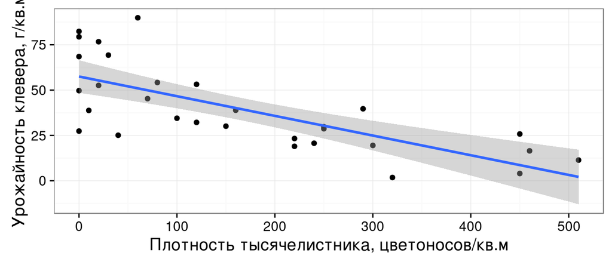

```r
library(ggplot2)
theme_set(theme_bw(base_size = 14)+ theme(legend.key = element_blank()))
gg_cl <- ggplot(data = clover, aes(y = Clover, x = Yarrow)) +
  geom_point() +
  labs(x = "Плотность тысячелистника, цветоносов/кв.м",
       y = "Урожайность клевера, г/кв.м")
gg_cl + geom_smooth(method = "lm")
```

## Не зная про несколько участков, мы бы просто подобрали обычную линейную регрессию

```r
M1 <- lm(Clover ~ Yarrow, data = clover)
summary(M1)
```

```
##
## Call:
## lm(formula = Clover ~ Yarrow, data = clover)
##
## Residuals:
##    Min     1Q Median     3Q    Max
## -30.09 -11.01  -2.18  10.58  38.92
##
## Coefficients:
##             Estimate Std. Error t value Pr(>|t|)
## (Intercept)  57.4913     4.3873    13.1  1.8e-13 ***
## Yarrow       -0.1086     0.0194    -5.6  5.4e-06 ***
## ---
## Signif. codes:  0 '***' 0.001 '**' 0.01 '*' 0.05 '.' 0.1 ' ' 1
##
## Residual standard error: 16.5 on 28 degrees of freedom
## Multiple R-squared:  0.529,  Adjusted R-squared:  0.512
## F-statistic: 31.4 on 1 and 28 DF,  p-value: 0.00000536
```

## Запишем уравнение этой линейной регрессии

```r
coef(M1) #Коэффициенты модели
```

```
## (Intercept)      Yarrow
##      57.491      -0.109
```

Уравнение:

Clover = 57.49 - 0.11Yarrow

Трактовка коэффциентов:

- \(b_0 =\) 57.491 - интерсепт. Это урожайность клевера, если нет тысячелистника
- \(b_1 =\) -0.109 - угол наклона. Он показывает на столько уменьшается урожайность клевера при увеличении плотности тысячелистника на 1 цветонос на кв.м

## Но мы знаем, что было несколько участков

Хорошо бы проверить, различается ли между участками зависимость урожайности клевера от плотности тысячелистника.

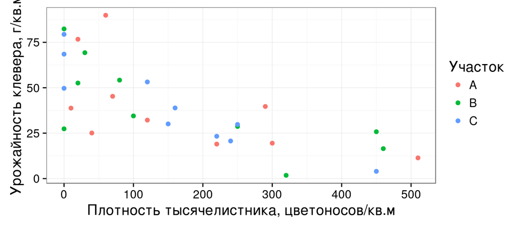

```r
gg_cl + aes(colour = Plot) + labs(colour = "Участок")
```

## Дискретные предикторы тоже можно включать в линейные модели.

Кодируем дискретный предиктор (фактор) при помощи числовых переменных-болванок (dummy variables) и можем пользоваться регрессией

Переменных болванок нужно на одну меньше, чем число уровней фактора

Для каждого из объектов каждая из болванок принимает значение 1 для своего уровня фактора

## Пробуем вручную создавать переменные-болванки

R может все сделать автоматически, но давайте попробуем вручную создать переменные-болванки и сравнить результаты с автоматическим способом.

В примере с клевером понадобится 2 переменных болванки

```r
clover$Plot_B <- as.numeric(clover$Plot == "B")
clover$Plot_C <- as.numeric(clover$Plot == "C")
```

Почему нам не нужна отдельная переменная-болванка для участка A?

## Почему нам не нужна отдельная переменная-болванка для участка A?

Потому что, если площадка с участка А, то `Plot_B` и `Plot_C` будут равны 0

```r
clover[, c("Plot", "Plot_B", "Plot_C")]
```

```
##    Plot Plot_B Plot_C
## 1     A      0      0
## 2     A      0      0
## 3     A      0      0
## 4     A      0      0
## 5     A      0      0
## 6     A      0      0
## 7     A      0      0
## 8     A      0      0
## 9     A      0      0
## 10    A      0      0
## 11    B      1      0
## 12    B      1      0
## 13    B      1      0
## 14    B      1      0
```

[output cut: 16 more lines]

## Подбираем параметры линейной модели

```r
M2_dummy <- lm(Clover ~ Yarrow + Plot_B + Plot_C, data = clover)
```

### На самом деле, мы можем сразу подобрать нужную модель с дискретным предиктором. В ручном создании болванок нет необходимости.

```r
M2 <- lm(Clover ~ Yarrow + Plot, data = clover)
```

Значения коэффициентов получатся одинаковые

```r
coef(M2)
```

```
## (Intercept)      Yarrow       PlotB       PlotC
##      57.577      -0.109       0.320      -0.543
```

```r
coef(M2_dummy)
```

```
## (Intercept)      Yarrow      Plot_B      Plot_C
##      57.577      -0.109       0.320      -0.543
```

## Смотрим на результаты линейной модели

### Внимание! Эта модель описывает три **параллельные линии** для каждого из уровней фактора Участок, поскольку не включает взаимодействие факторов

```r
summary(M2)
```

```
##
## Call:
## lm(formula = Clover ~ Yarrow + Plot, data = clover)
##
## Residuals:
##    Min     1Q Median     3Q    Max
## -30.50 -10.54  -2.58  10.91  38.84
##
## Coefficients:
##             Estimate Std. Error t value     Pr(>|t|)
## (Intercept)  57.5772     6.3371    9.09 0.0000000015 ***
## Yarrow       -0.1086     0.0201   -5.40 0.0000116947 ***
## PlotB         0.3205     7.6534    0.04         0.97
## PlotC        -0.5432     7.6527   -0.07         0.94
## ---
## Signif. codes:  0 '***' 0.001 '**' 0.01 '*' 0.05 '.' 0.1 ' ' 1
##
## Residual standard error: 17.1 on 26 degrees of freedom
## Multiple R-squared:  0.529,  Adjusted R-squared:  0.474
## F-statistic: 9.73 on 3 and 26 DF,  p-value: 0.000177
```

## Попробуем записать уравнение модели, где появился дискретный предиктор

```r
coef(M2)
```

```
## (Intercept)      Yarrow       PlotB       PlotC
##      57.577      -0.109       0.320      -0.543
```

Уравнение:

Clover = 57.58 - 0.11Yarrow + 0.32PlotB - 0.54PlotC

Трактовка коэффциентов:

- \(b_0 =\) 57.58 - интерцепт, урожайность клевера **на базовом уровне (на участке A)**, если нет тысячелистника

Общий угол наклона:

- \(b_1 =\) -0.11 - на столько уменьшается урожайность клевера на любом участке при увеличении плотности тысячелистника на 1 цветонос на кв.м

Поправки для интерцепта:

- \(b_2 =\) 0.32 - отличие урожайности клевера **на участке B от участка A**
- \(b_3 =\) -0.54 - отличие урожайности клевера **на участке C от участка A**

## Давайте запишем отдельные уравнения для каждого типа участков

Общее уравнение модели с параллельными линиями:

Clover = 57.58 - 0.11Yarrow + 0.32PlotB - 0.54PlotC

Для участка A:

Clover = 57.58 - 0.11 Yarrow

Для участка B:

Clover = (57.58 + 0.32) - 0.11 Yarrow = 57.9 - 0.11 Yarrow

Для участка C:

Clover = (57.58 - 0.54) - 0.11 Yarrow = 57.04 - 0.11 Yarrow

## Базовый уровень

Уровень дискретного предиктора, для записи которого мы не использовали отдельную переменную-болванку, называется базовым.

Интерцепт в уравнении регрессии описывает среднее значение предиктора на базовом уровне.

В R базовым уровнем считается первый уровень фактора

```r
levels(clover$Plot)
```

```
## [1] "A" "B" "C"
```

В данном случае это уровень "A"

## Что произойдет с моделью, если мы изменим базовый уровень?

```r
clover$Plot <- relevel(clover$Plot, ref = "C")
levels(clover$Plot) # Теперь первым идет "C"
```

```
## [1] "C" "A" "B"
```

```r
M2_C <- lm(Clover ~ Yarrow + Plot, data = clover)
summary(M2_C)
```

```
##
## Call:
## lm(formula = Clover ~ Yarrow + Plot, data = clover)
##
## Residuals:
##    Min     1Q Median     3Q    Max
## -30.50 -10.54  -2.58  10.91  38.84
##
## Coefficients:
##             Estimate Std. Error t value     Pr(>|t|)
## (Intercept)  57.0340     6.2853    9.07 0.0000000015 ***
## Yarrow       -0.1086     0.0201   -5.40 0.0000116947 ***
## PlotA         0.5432     7.6527    0.07         0.94
## PlotB         0.8637     7.6559    0.11         0.91
## ---
## Signif. codes:  0 '***' 0.001 '**' 0.01 '*' 0.05 '.' 0.1 ' ' 1
##
## Residual standard error: 17.1 on 26 degrees of freedom
## Multiple R-squared:  0.529,  Adjusted R-squared:  0.474
## F-statistic: 9.73 on 3 and 26 DF,  p-value: 0.000177
```

## Изменился ли смысл модели от смены уровней? Нет!

```r
coef(M2)
```

```
## (Intercept)      Yarrow       PlotB       PlotC
##      57.577      -0.109       0.320      -0.543
```

Clover = 57.58 - 0.11Yarrow + 0.32PlotB - 0.54PlotC

Трактовка коэффциентов:  
- \(b_0 =\) 57.58 - интерцепт, урожайность клевера **на базовом уровне (на участке A)**, если нет тысячелистника

Общий угол наклона:  
- \(b_1 =\) -0.11 - на столько уменьшается урожайность клевера на любом участке при увеличении плотности тысячелистника на 1 цветонос на кв.м

Поправки для интерцепта:  
- \(b_2 =\) 0.32 - отличие урожайности клевера **на участке B от участка A** - \(b_3 =\) -0.54 - отличие урожайности клевера **на участке C от участка A**

```r
coef(M2_C)
```

```
## (Intercept)      Yarrow       PlotA       PlotB
##      57.034      -0.109       0.543       0.864
```

Clover = 57.03 - 0.11Yarrow + 0.54PlotA + 0.86PlotB

Трактовка коэффциентов:  
- \(b_0 =\) 57.03 - интерцепт, урожайность клевера **на базовом уровне (на участке С)**, если нет тысячелистника

Общий угол наклона:  
- \(b_1 =\) -0.11 - на столько уменьшается урожайность клевера на любом участке при увеличении плотности тысячелистника на 1 цветонос на кв.м

Поправки для интерцепта:  
- \(b_2 =\) 0.54 - отличие урожайности клевера **на участке A от участка C** - \(b_3 =\) 0.86 - отличие урожайности клевера **на участке B от участка C**

## Изменился ли смысл модели от смены уровней?

### Даже уравнения для каждой из прямых остались прежними в пределах ошибки округления

Общее уравнение модели с параллельными линиями:

Clover = 57.58 - 0.11Yarrow + 0.32PlotB - 0.54PlotC

Для участка A:

Clover = 57.58 - 0.11 Yarrow

Для участка B:

Clover = (57.58 + 0.32) - 0.11 Yarrow =  
= 57.9 - 0.11 Yarrow

Для участка C:

Clover = (57.58 - 0.54) - 0.11 Yarrow =  
= 57.04 - 0.11 Yarrow

Общее уравнение модели с параллельными линиями:

Clover = 57.03 - 0.11Yarrow + 0.54PlotA + 0.86PlotB

Для участка A:

Clover = (57.03 + 0.54) - 0.11 Yarrow =  
= 57.57 - 0.11 Yarrow

Для участка B:

Clover = (57.03 + 0.86) - 0.11 Yarrow =  
= 57.89 - 0.11 Yarrow

Для участка C:

Clover = 57.03 - 0.11 Yarrow

## График модели с одинаковыми углами наклона

Нужны исходные данные с предсказанными значениями и стандартными ошибками. При этом хорошо бы, чтобы диапазоны предикторов для каждого из уровней дискретной переменной соответствовали реальным значениям.

Решение средствами пакета `plyr`:

```r
library(plyr)
# делим датафрейм на части по переменной Plot
# по каждой из частей считаем при помощи summarise
# последовательность от мин. до макс. значения Yarrow
my_df <- plyr::ddply(clover, .(Plot),
    summarise,
    Yarrow = seq(min(Yarrow),  max(Yarrow), length = 10))
# Считаем предсказанные значения и стандартные ошибки
M2_pred <- predict(M2, newdata = my_df, se.fit = TRUE)
# Добавляем их в датафрейм
my_df$Clover <- M2_pred$fit
my_df$SE <- M2_pred$se.fit
```

## Самостоятельно попробуйте разобрать, как сделать тот же самый исходный датафрейм в пакете dplyr

```r
# Выгружаем plyr, потому что dplyr конфликтует с plyr
detach("package:plyr", unload=TRUE)
library(dplyr)
# Разбиваем clover на группы по переменной Plot
# и считаем минимум и максимум Yarrow
minmax <- clover %>% group_by(Plot) %>%
  summarise(mYarrow = min(Yarrow),
  MYarrow = max(Yarrow))
# Pазбиваем minmax по переменной Plot создаем датафрейм,
# где Yarrow - это последовательность от минимума до максимума для данного Plot,
# снимаем группировку,
# добавляем предсказанные значения и стандартные ошибки
my_df <- minmax %>% group_by(Plot) %>%
  do(data.frame(Yarrow = seq(.$mYarrow, .$MYarrow, length = 10))) %>%
  ungroup %>%
  mutate(Clover = predict(M2, newdata = .),
    SE = predict(M2, newdata = ., se.fit = TRUE)$'se.fit')
```

## Строим график с параллельными прямыми

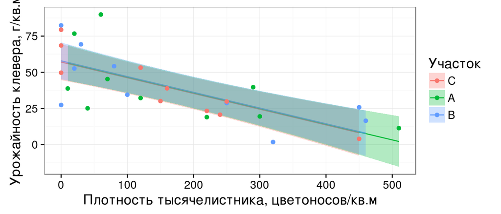

```r
gg_cl_parallel <- ggplot(data = my_df, aes(y = Clover, x = Yarrow, colour = Plot, fill = Plot)) +
  geom_line() +
  geom_ribbon(aes(ymax = Clover + 1.98 * SE,
                  ymin = Clover - 1.98 * SE),
              alpha = 0.3, colour = NA) +
    geom_point(data = clover) +
  labs(colour = "Участок", fill = "Участок",
       x = "Плотность тысячелистника, цветоносов/кв.м",
       y = "Урожайность клевера, г/кв.м")
gg_cl_parallel
```

## Добавим отдельные панели

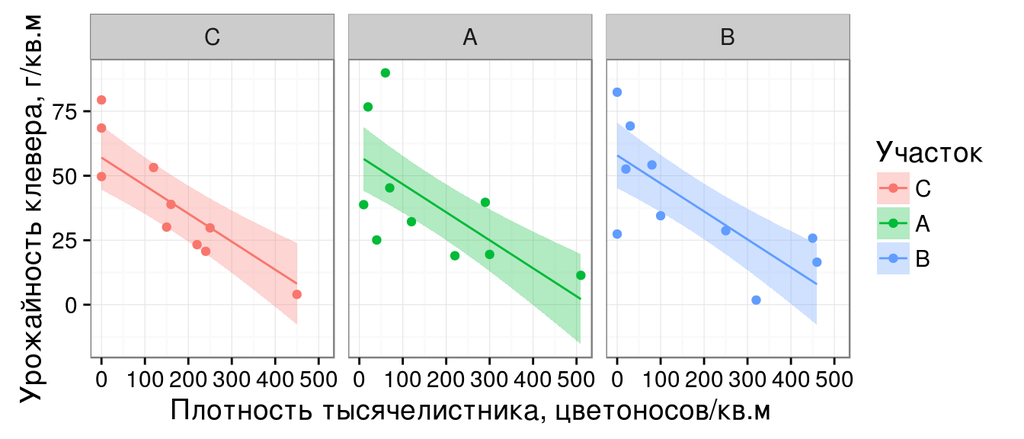

```r
gg_cl_parallel + facet_wrap(~ Plot)
```

## Но может быть линии на самом деле не параллельны?

### Мы должны были начать с этой, полной, модели!!!

Чтобы проверить, одинаковы ли зависимости для каждого из участков, нам нужно подобрать модель со взаимодействием и протестировать его значимость.

```r
# вернем уровни на место в прежнем порядке
clover$Plot <- factor(clover$Plot, levels = c("A", "B", "C"), labels = c("A", "B", "C"))
M3 <- lm(Clover ~ Yarrow * Plot, data = clover)
coef(M3)
```

```
##  (Intercept)       Yarrow        PlotB        PlotC Yarrow:PlotB Yarrow:PlotC
##     55.21877     -0.09426      0.60566      8.08139     -0.00226     -0.05379
```

Общее уравнение:  
Clover = 55.219 - 0.094Yarrow + 0.606PlotB + 8.081PlotC - 0.002Yarrow:PlotB - 0.054Yarrow:PlotC

Трактовка коэффциентов:  
- \(b_0 =\) 55.219 - урожайность клевера, если нет тысячелистника (на участке A, а для других - с учетом поправки)  
- \(b_1 =\) -0.094 - угол наклона прямой (для участка А, а для других - с учетом поправок)

Поправки интерсепта:  
- \(b_2 =\) 0.606 - для участка B  
- \(b_3 =\) 8.081 - для участка C

Поправки угла наклона:  
- \(b_4 =\) -0.002 - для участка B  
- \(b_5 =\) -0.054 - для участка C

## Чтобы лучше понять смысл коэффициентов, давайте запишем отдельные уравнения для каждого типа участков

Общее уравнение модели с разными углами наклона:

Clover = 55.219 - 0.094Yarrow + 0.606PlotB + 8.081PlotC - 0.002Yarrow:PlotB - 0.054Yarrow:PlotC

Для участка A:

Clover = 55.219 - 0.094 Yarrow

Для участка B:

Clover = (55.219 + 0.606) + (- 0.094 - 0.002) Yarrow = 55.825 - 0.096 Yarrow

Для участка C:

Clover = (55.219 + 8.081) + (- 0.094 - 0.054) Yarrow = 63.3 - 0.148 Yarrow

## График с разными углами наклона

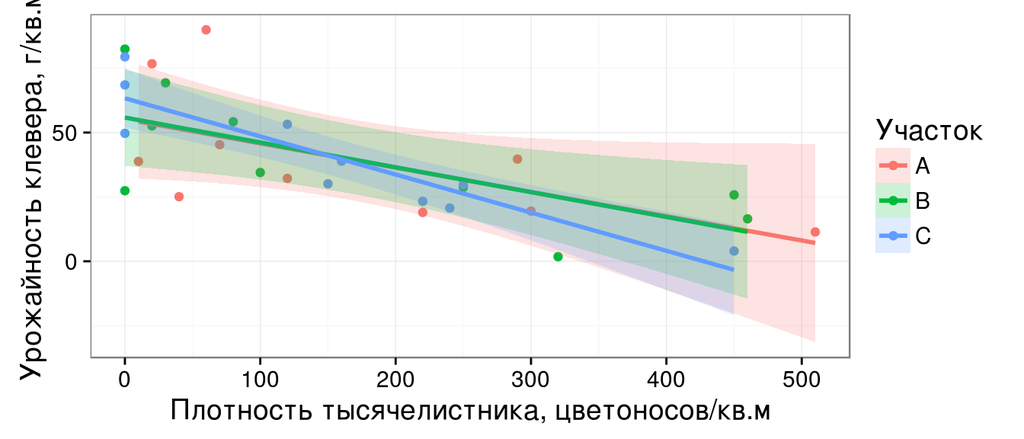

```r
gg_cl + aes(colour = Plot, fill = Plot) +
  geom_smooth(method = "lm", alpha = 0.2) +
  labs(colour = "Участок", fill = "Участок")
```

## Проверяем условия применимости

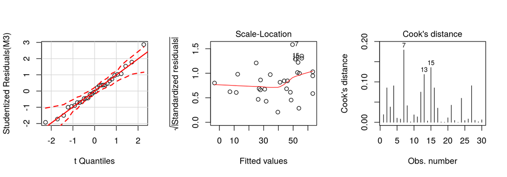

```r
library(car)
op <- par(mfrow = c(1, 3), cex = 1)
qqPlot(M3)
plot(M3, which = 3)
plot(M3, which = 4)
par(op)
```

Есть подозрение на гетерогенность дисперсий

## Проверим остатки на гетерогенность дисперсий тестом Бройша-Пагана

```r
library(lmtest)
bptest(M3)
```

```
##
##  studentized Breusch-Pagan test
##
## data:  M3
## BP = 9, df = 5, p-value = 0.1
```

Все в порядке, можно продолжать

## Как проверить, действительно ли различается урожайность между участками?

### 1 способ:

При помощи частного F-критерия можно сравнить полную и уменьшенную модель

На первом этапе пробуем удалить только взаимодействие

```r
drop1(M3, test = "F")
```

```
## Single term deletions
##
## Model:
## Clover ~ Yarrow * Plot
##             Df Sum of Sq  RSS AIC F value Pr(>F)
## <none>                   7237 177
## Yarrow:Plot  2       375 7612 174    0.62   0.55
```

При удалении взаимодействия модель не ухудшается. Взаимодействие можно не учитывать

## Как проверить, действительно ли различается урожайность между участками?

### 1 способ (продолжение):

Подбираем модель без взаимодействия. На самом деле, мы это уже делали. Это M2

```r
# M2 <- lm(Clover ~ Yarrow + Plot, data = clover)
drop1(M2, test = "F")
```

```
## Single term deletions
##
## Model:
## Clover ~ Yarrow + Plot
##        Df Sum of Sq   RSS AIC F value   Pr(>F)
## <none>               7612 174
## Yarrow  1      8541 16153 195   29.17 0.000012 ***
## Plot    2         4  7616 170    0.01     0.99
## ---
## Signif. codes:  0 '***' 0.001 '**' 0.01 '*' 0.05 '.' 0.1 ' ' 1
```

При удалении Plot модель не ухудшается - выкидываем Plot

## Как проверить, действительно ли различается урожайность между участками?

### 1 способ (продолжение):

Подбираем модель без Plot На самом деле, мы это уже делали. Это M1

```r
# M1 <- lm(Clover ~ Yarrow, data = clover)
drop1(M1, test = "F")
```

```
## Single term deletions
##
## Model:
## Clover ~ Yarrow
##        Df Sum of Sq   RSS AIC F value    Pr(>F)
## <none>               7616 170
## Yarrow  1      8538 16154 191    31.4 0.0000054 ***
## ---
## Signif. codes:  0 '***' 0.001 '**' 0.01 '*' 0.05 '.' 0.1 ' ' 1
```

Из этой модели уже ничего не выкинуть

## Как проверить, действительно ли различается урожайность между участками?

### 2 способ:

Можно провести дисперсионный анализ одним из способов (подробнее в следующей лекции)

```r
# anova(M3)        # способ А
# summary(aov(M3)) # способ Б
library(car)     # способ В
Anova(M3)
```

```
## Anova Table (Type II tests)
##
## Response: Clover
##             Sum Sq Df F value   Pr(>F)
## Yarrow        8541  1   28.32 0.000018 ***
## Plot             4  2    0.01     0.99
## Yarrow:Plot    375  2    0.62     0.55
## Residuals     7237 24
## ---
## Signif. codes:  0 '***' 0.001 '**' 0.01 '*' 0.05 '.' 0.1 ' ' 1
```

## После подбора финальной модели нужно еще раз проверить условия применимости

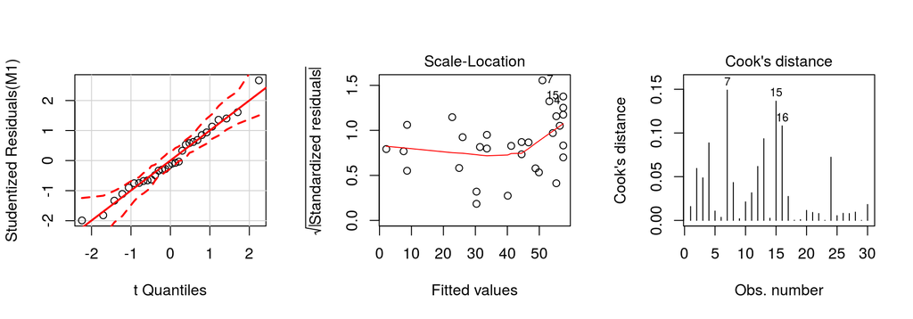

```r
op <- par(mfrow = c(1, 3), cex = 1)
qqPlot(M1)
plot(M1, which = 3)
plot(M1, which = 4)
par(op)
```

Есть подозрение на гетерогенность дисперсий

## Проверим остатки на гетерогенность дисперсий тестом Бройша-Пагана

```r
bptest(M1)
```

```
##
##  studentized Breusch-Pagan test
##
## data:  M1
## BP = 3, df = 1, p-value = 0.06
```

На грани. Если рассуждать формально, то можно продолжать.

Модель M1 - финальная

```r
coef(M1)
```

```
## (Intercept)      Yarrow
##      57.491      -0.109
```

Clover = 57.49 - 0.11Yarrow

## Пример: Козы и глисты

Как влияет на прирост массы коз интенсивность профилактики паразитарных заболеваний?

Известно, что у легких животных привес больше, поэтому мы должны учитывать в модели не только способ обработки от глистов, но и влияние начального веса.

- Treatment - обработка от глистов (стандартная, интенсивная)
- Weightgain - привес, кг
- Initial.wt - начальный вес, кг

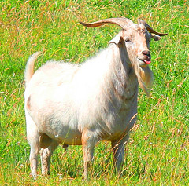

Goat by Jennifer C. [on Flickr](https://flic.kr/p/fjU4J9)

Пример из библиотеки данных  
http://www.statlab.uni-heidelberg.de/data/ancova/goats.story.html

## Читаем и знакомимся с данными

```r
goat <- read.delim("data/goats.csv")
str(goat)
```

```
## 'data.frame':    40 obs. of  3 variables:
##  $ Treatment : Factor w/ 2 levels "intensive","standard": 2 2 2 2 2 2 2 2 2 2 ...
##  $ Weightgain: int  5 3 8 7 6 4 8 6 7 5 ...
##  $ Initial.wt: int  21 24 21 22 23 26 22 23 24 20 ...
```

```r
# переименуем переменные для краткости
colnames(goat) <- c("treat", "wt", "init")
any(is.na(goat))
```

```
## [1] FALSE
```

```r
table(goat$treat)
```

```
##
## intensive  standard
##        20        20
```

## Проверим порядок уровней фактора

```r
levels(goat$treat)
```

```
## [1] "intensive" "standard"
```

Хорошо бы поменять их местами для удобства интерпретации

```r
goat$treat <- relevel(goat$treat, ref = "standard")
```

## Задание

1. Подберите модель, описывающую зависимость между увеличением веса коз и способом прфилактической обработки животных.
2. Проверьте условия применимости этой модели
3. Попробуйте сократить модель, чтобы она стала оптимальной.
4. Проверьте условия применимости финальной модели.

## Решение

Необходимо учитывать ковариату - начальный вес, кроме того, нужно проверить, нет ли взаимодействия способа обработки от глистов и начального веса

```r
MG1 <- lm(wt ~ treat * init, data = goat)
```

Формула модели со взаимодействием выглядит в сокращенном виде так:

wt ~ treat * init

а в полном виде то же самое выглядит так:

wt ~ treat + init + treat:init

## График модели со взаимодействием

Похоже, что взаимодействие не будет достоверным. Если это и вправду так, то этот график нам больше не понадобится.

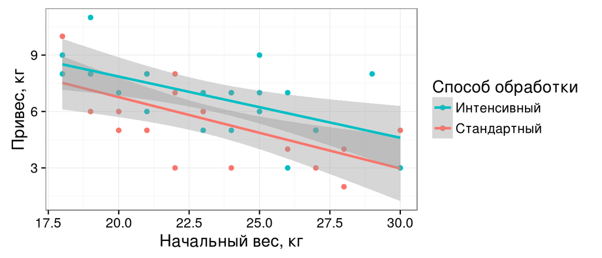

```r
gg_g <- ggplot(data = goat, aes(y = wt, x = init, colour = treat)) +
  geom_point()  +
  labs(x = "Начальный вес, кг",
       y = "Привес, кг") +
  scale_colour_discrete("Способ обработки", breaks = c("intensive", "standard"), labels = c("Интенсивный", "Стандартный"))
gg_g + geom_smooth(method = "lm")
```

## Проверяем условия применимости

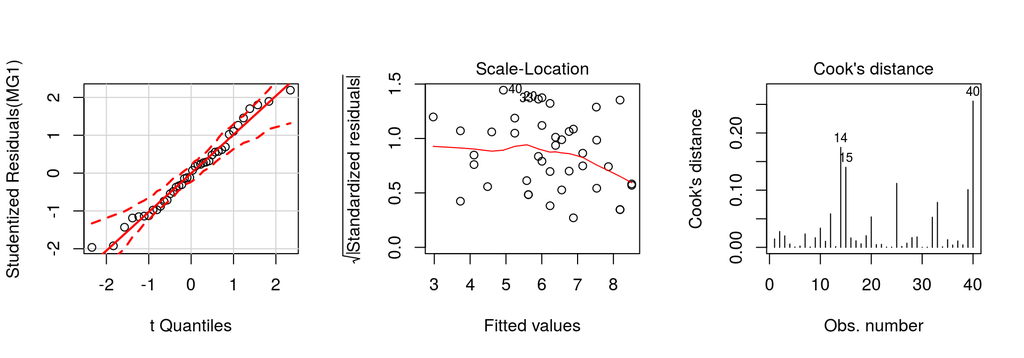

```r
op <- par(mfrow = c(1, 3), cex = 1)
qqPlot(MG1)
plot(MG1, which = 3)
plot(MG1, which = 4)
par(op)
```

Все хорошо

## Выбор оптимальной модели

Пробуем удалить взаимодействие

```r
drop1(MG1, test = "F")
```

```
## Single term deletions
##
## Model:
## wt ~ treat * init
##            Df Sum of Sq  RSS  AIC F value Pr(>F)
## <none>                  96.5 43.2
## treat:init  1     0.342 96.9 41.4    0.13   0.72
```

Можно удалять

## Удаляем взаимодействие и пробуем упростить дальше

```r
MG2 <- update(MG1, .~. - treat:init)
drop1(MG2, test = "F")
```

```
## Single term deletions
##
## Model:
## wt ~ treat + init
##        Df Sum of Sq   RSS  AIC F value   Pr(>F)
## <none>               96.9 41.4
## treat   1      16.0 112.9 45.5    6.11    0.018 *
## init    1      58.6 155.5 58.3   22.40 0.000032 ***
## ---
## Signif. codes:  0 '***' 0.001 '**' 0.01 '*' 0.05 '.' 0.1 ' ' 1
```

Дальше упростить не получится. Вот наша оптимальная модель

## Проверяем условия применимости финальной модели

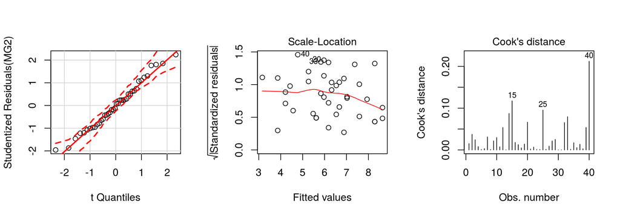

```r
op <- par(mfrow = c(1, 3), cex = 1)
qqPlot(MG2)
plot(MG2, which = 3)
plot(MG2, which = 4)
par(op)
```

Все в порядке

## Проверяем значимость коэффициентов

```r
summary(MG2)
```

```
##
## Call:
## lm(formula = wt ~ treat + init, data = goat)
##
## Residuals:
##    Min     1Q Median     3Q    Max
## -2.972 -1.242 -0.034  0.988  3.223
##
## Coefficients:
##                Estimate Std. Error t value     Pr(>|t|)
## (Intercept)     13.7017     1.7599    7.79 0.0000000026 ***
## treatintensive   1.2649     0.5117    2.47        0.018 *
## init            -0.3514     0.0742   -4.73 0.0000320779 ***
## ---
## Signif. codes:  0 '***' 0.001 '**' 0.01 '*' 0.05 '.' 0.1 ' ' 1
##
## Residual standard error: 1.62 on 37 degrees of freedom
## Multiple R-squared:  0.438,  Adjusted R-squared:  0.408
## F-statistic: 14.4 on 2 and 37 DF,  p-value: 0.0000233
```

## Записываем уравнение модели

```r
coef(MG2)
```

```
##    (Intercept) treatintensive           init
##         13.702          1.265         -0.351
```

Уравнение:

wt = 13.70 + 1.26treatintensive - 0.35init

Привес коз при интенсивной обработке от глистов на 1.26 кг выше, чем при стандартном методе обработки (t-тест, p < 0.05)

## Данные для графика с параллельными прямыми

Решение средствами пакета `plyr`:

```r
# делим датафрейм на части по переменной treat
# по каждой из частей считаем
# последовательность от мин. до макс. значения Yarrow
my_df <- plyr::ddply(goat, .(treat),
    summarise,
    init = seq(min(init),  max(init), length = 10))
# Считаем предсказанные значения и стандартные ошибки
MG2_pred <- predict(MG2, newdata = my_df, se.fit = TRUE)
# Добавляем их в датафрейм
my_df$wt <- MG2_pred$fit
my_df$SE <- MG2_pred$se.fit
```

## Самостоятельно попробуйте разобрать, как сделать тот же самый исходный датафрейм в пакете dplyr

```r
library(dplyr)
my_df <- goat %>%
  group_by(treat) %>%
  summarise(min_init = min(init),
  max_init = max(init)) %>% group_by(treat) %>%
  do(data.frame(init = seq(.$min_init, .$max_init, length = 10))) %>%
  ungroup %>%
  mutate(wt = predict(MG2, newdata = .),
    SE = predict(MG2, newdata = ., se.fit = TRUE)$'se.fit')
```

## Строим график

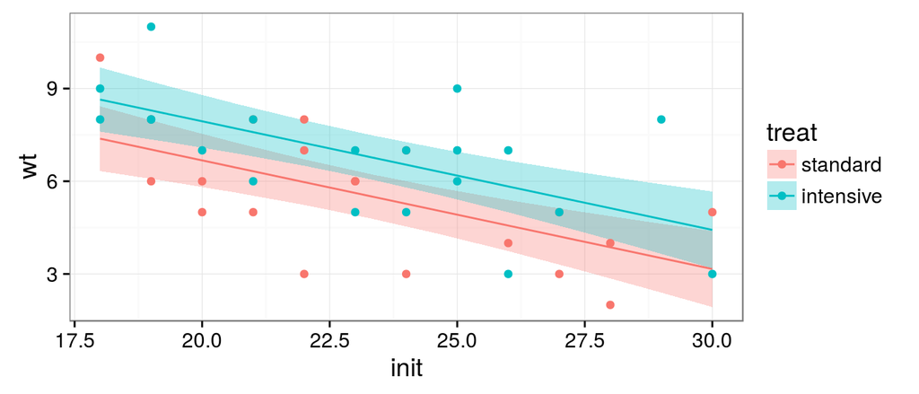

```r
gg_g_parallel <-
  ggplot(data = my_df, aes(y = wt, x = init, fill = treat, colour = treat)) +
  geom_line() +
  geom_ribbon(alpha = 0.3,
              aes(ymax = wt + 1.98 * SE,
                  ymin = wt - 1.98 * SE), colour = NA) +
  geom_point(data = goat)
gg_g_parallel
```

## Подписываем оси

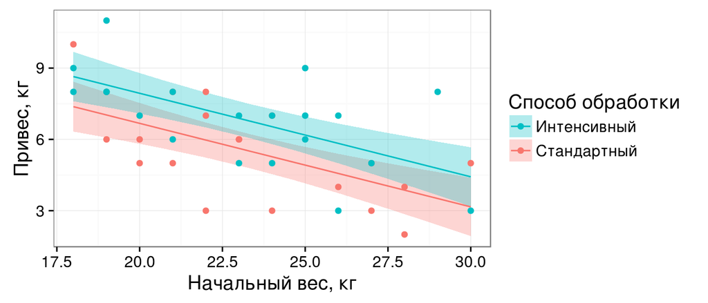

```r
gg_g_parallel +
  labs(x = "Начальный вес, кг", y = "Привес, кг") +
  scale_colour_discrete("Способ обработки", breaks = c("intensive", "standard"),
                        labels = c("Интенсивный", "Стандартный")) +
  scale_fill_discrete("Способ обработки", breaks = c("intensive", "standard"),
                      labels = c("Интенсивный", "Стандартный"))
```

## Take home messages

- Коэффициенты регрессии при дискретных предикторах позволяют сопоставить средние значения для каждого уровня фактора со средним значением для базового уровня.
- При изменении базового уровня, коэффициенты изменятся, но суть модели останется той же.
- В одной модели можно объединить как непрерывные, так и дискретные предикторы.
- При анализе экспериметальных данных, включение в анализ некоторых ковариат может помочь лучше увидеть закономерности.

## Что почитать

- Quinn G.P., Keough M.J. (2002) Experimental design and data analysis for biologists, `Chapter 12`.